# Trees and (random)Forests

Adi Sarid / adi@sarid-ins.co.il

In this chapter we discuss two methods for prediction and regression: trees and random forests.

The general idea of trees is to split the variable space, each time by a different variable, until reaching a “leaf” - an area small enough such that “most” of the observations in it belong to the same class (or with a small variance).

Trees are visually appealing, but they tend to be lousy predictors, hence, a common generalization is a random forest, which generates many trees and then averages them.

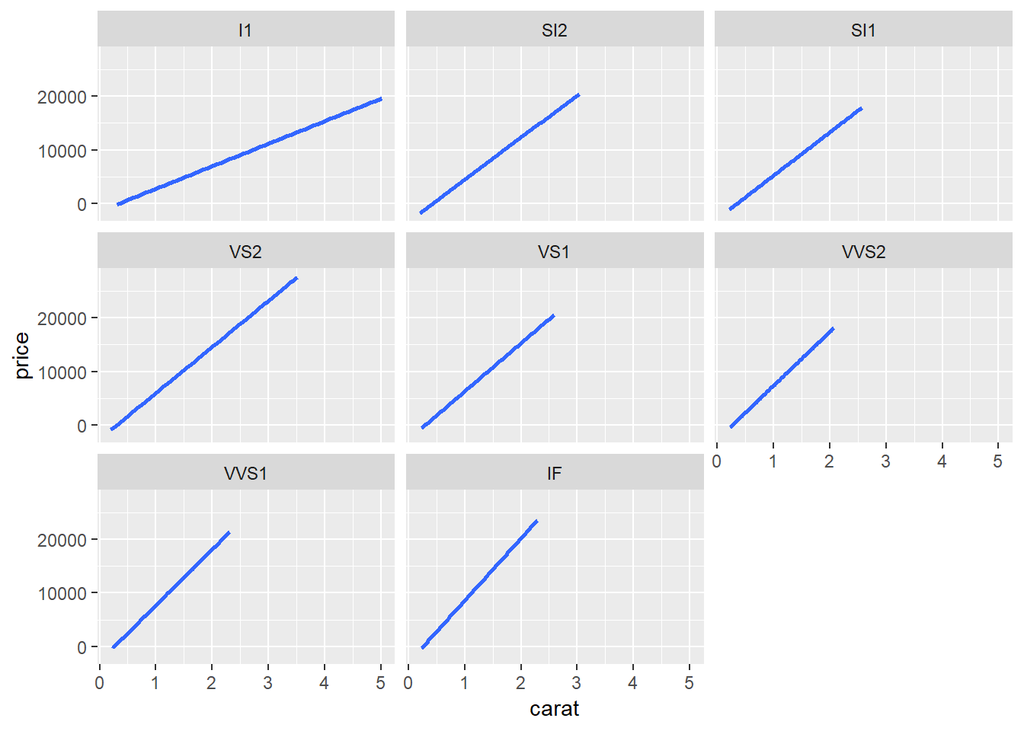

```r
library(tidyverse)

ggplot(diamonds, aes(y = price, x = carat)) +
  facet_wrap(~ clarity) +
  stat_smooth(method = "lm")
```

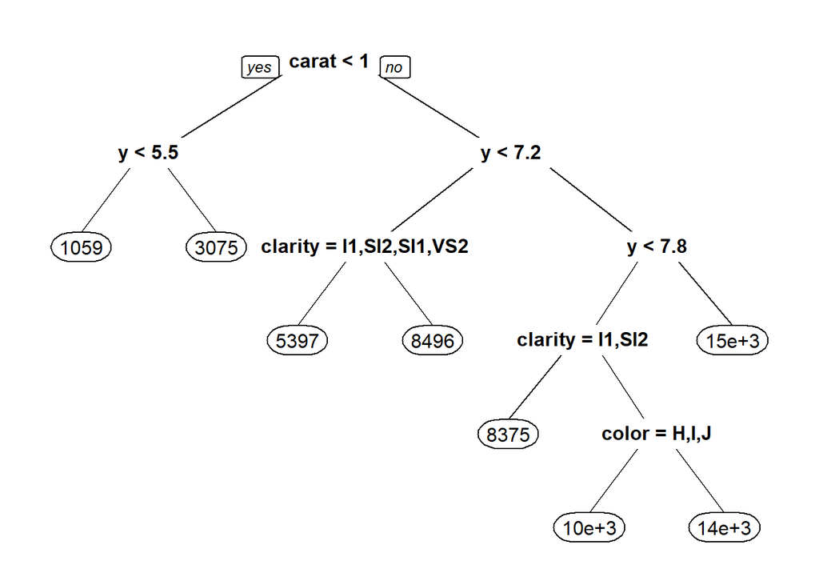

```r
library(rpart)

diamond_price_tree <- rpart(formula = price ~ .,
                            data = diamonds)

library(rpart.plot)
prp(diamond_price_tree)
```

```r
diamond_price_tree
```

```
## n= 53940
##
## node), split, n, deviance, yval
##       * denotes terminal node
##
##  1) root 53940 858473100000  3932.800
##    2) carat< 0.995 34880  43459420000  1632.641
##      4) y< 5.535 24951   6860691000  1058.546 *
##      5) y>=5.535 9929   7710112000  3075.309 *
##    3) carat>=0.995 19060 292761600000  8142.115
##      6) y< 7.195 12884  60679350000  6137.844
##       12) clarity=I1,SI2,SI1,VS2 9804  20256360000  5397.093 *
##       13) clarity=VS1,VVS2,VVS1,IF 3080  17919640000  8495.739 *
##      7) y>=7.195 6176  72354930000 12323.300
##       14) y< 7.815 3945  33996520000 10899.960
##         28) clarity=I1,SI2 954   3380193000  8375.178 *
##         29) clarity=SI1,VS2,VS1,VVS2,VVS1,IF 2991  22595360000 11705.260
##           58) color=H,I,J 1554   5588830000 10014.970 *
##           59) color=D,E,F,G 1437   7765314000 13533.160 *
##       15) y>=7.815 2231  16233830000 14840.160 *
```

```r
summary(diamond_price_tree)
```

```
## Call:
## rpart(formula = price ~ ., data = diamonds)
##   n= 53940
##
##           CP nsplit  rel error    xerror        xstd
## 1 0.60834997      0 1.00000000 1.0000305 0.008800624
## 2 0.18605980      1 0.39165003 0.3917115 0.003926297
## 3 0.03365116      2 0.20559023 0.2056319 0.002060660
## 4 0.02621322      3 0.17193908 0.1720864 0.002057741
## 5 0.02577201      4 0.14572586 0.1451525 0.001775541
## 6 0.01005400      5 0.11995385 0.1207523 0.001559691
## 7 0.01000000      7 0.09984584 0.1080150 0.001414337
##
## Variable importance
##   carat       y       x       z clarity   color
##      25      24      24      23       3       1
##
## Node number 1: 53940 observations,    complexity param=0.60835
##   mean=3932.8, MSE=1.591533e+07
##   left son=2 (34880 obs) right son=3 (19060 obs)
##   Primary splits:
##       carat < 0.995 to the left,  improve=0.60835000, (0 missing)
##       y     < 6.345 to the left,  improve=0.60688030, (0 missing)
##       x     < 6.335 to the left,  improve=0.60323470, (0 missing)
##       z     < 3.915 to the left,  improve=0.59819760, (0 missing)
##       color splits as  LLLLRRR,   improve=0.02222238, (0 missing)
##   Surrogate splits:
##       x       < 6.275 to the left,  agree=0.984, adj=0.953, (0 split)
##       y       < 6.285 to the left,  agree=0.981, adj=0.946, (0 split)
##       z       < 3.895 to the left,  agree=0.978, adj=0.937, (0 split)
##       clarity splits as  RRLLLLLL,  agree=0.679, adj=0.091, (0 split)
##       color   splits as  LLLLLRR,   agree=0.660, adj=0.039, (0 split)
##
## Node number 2: 34880 observations,    complexity param=0.03365116
##   mean=1632.641, MSE=1245969
##   left son=4 (24951 obs) right son=5 (9929 obs)
##   Primary splits:
##       y       < 5.535 to the left,  improve=0.66472620, (0 missing)
##       carat   < 0.625 to the left,  improve=0.66450550, (0 missing)
##       x       < 5.485 to the left,  improve=0.66202330, (0 missing)
```

[output cut: 93 more lines]

```
##       carat   < 1.615 to the left,  improve=0.05752247, (0 missing)
##       y       < 7.595 to the left,  improve=0.05099388, (0 missing)
##       z       < 4.715 to the left,  improve=0.04452641, (0 missing)
##   Surrogate splits:
##       carat < 1.545 to the right, agree=0.562, adj=0.089, (0 split)
##       z     < 4.595 to the right, agree=0.556, adj=0.076, (0 split)
##       y     < 7.325 to the right, agree=0.538, adj=0.038, (0 split)
##       x     < 7.435 to the right, agree=0.538, adj=0.038, (0 split)
##       depth < 60.85 to the right, agree=0.537, adj=0.037, (0 split)
##
## Node number 58: 1554 observations
##   mean=10014.97, MSE=3596416
##
## Node number 59: 1437 observations
##   mean=13533.16, MSE=5403837
```

As the tree becomes “depper” we’re prone to more overfitting errors. Here is an example for a very deep tree (which is probably not very effective).

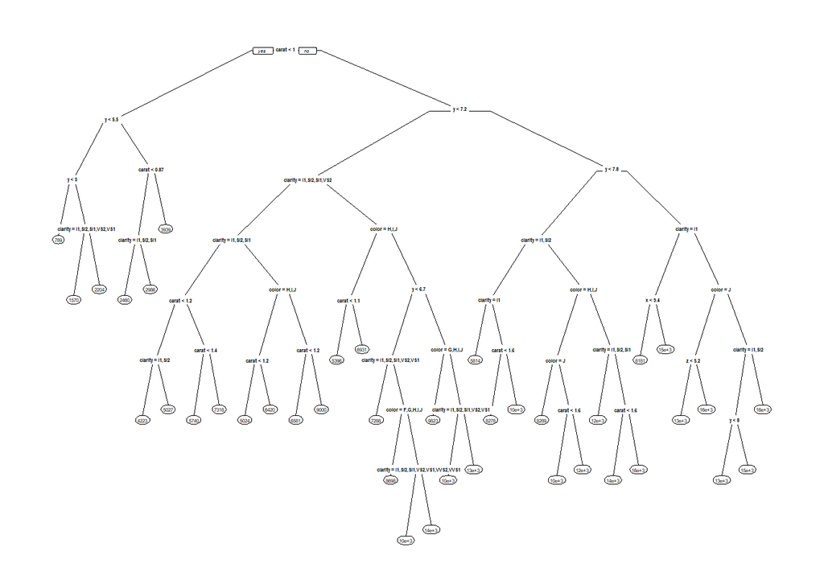

```r
diamond_price_tree_large <- rpart(formula = price ~ .,
                                  data = diamonds,
                                  control = rpart.control(cp = 0.0005, xval = 10))
prp(diamond_price_tree_large)
```

```r
#summary(diamond_price_tree_large)
```

A complexity parameter controls the tree’s depth. When the paramter is low, the algorithm tends to perform more splits (the CP acts as a split threshold).

To get back to a smaller tree, we can prune the tree, similar to what we did in a step-wise selection algorithm in regression.

How do the algorithms work?

## Growing and prunning trees

The algorithms divide the space of observations into “hyper-planes” (half-spaces) each time, and predicting the target variable according to the resulting division, minimizing:

$$\sum_{j=1}^J\sum_{i\in R_j}\left(y_i-\hat{y}_{R_j}\right)^2$$

Where $j$ is the number of half-spaces dividing the feature space $X$.

At each step of the algorithm the “best split” is examined, looking for the feature and cutpoint which minimizes:

$$\sum_{i: x_i\in R_1(j,s)}\left(y_i-\hat{y}_{R_1}\right)^2 + \sum_{i: x_i\in R_2(j,s)}\left(y_i-\hat{y}_{R_2}\right)^2$$

Where:

$$R_1(j,s) = \left\{X|X_j<s\right\} \text{ and } R_2(j,s) = \left\{X|X_j\geq s\right\}$$

This is what’s called a greedy algorithm (at each step looking for current best cutpoint).

### Prunning

To prune a tree we can use `prune`.

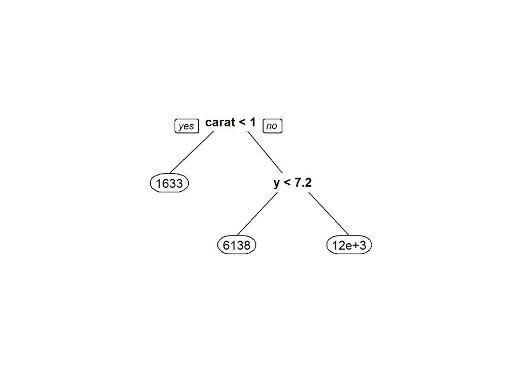

```r
diamond_price_pruned <- prune(diamond_price_tree_large, cp = 0.05)

prp(diamond_price_pruned)
```

## Using cross-validation to choose the complexity parameter

To choose CP, one can use cross-validation, what cross validation does is:

- Chooses a CP
- SPlit the original data to $k$ data sets (k-fold cross validation, $k=10$ is a common choice).
- For $\frac{k-1}{k}$ of the data fit a tree using the chosen CP.
- You get $k$ errors, in other words for each CP we get a distribution of errors.
- Repeat the process for various values of CP.

The `rpart` algorithm actually does all this for us:

```r
# here is the cp table
diamond_price_tree_large$cptable
```

```
##              CP nsplit  rel error     xerror         xstd
## 1  0.6083499681      0 1.00000000 1.00004271 0.0088007288
## 2  0.1860597998      1 0.39165003 0.39171061 0.0039264264
## 3  0.0336511552      2 0.20559023 0.20564992 0.0020607881
## 4  0.0262132207      3 0.17193908 0.17205375 0.0020581019
## 5  0.0257720103      4 0.14572586 0.14192334 0.0017426066
## 6  0.0100540028      5 0.11995385 0.12048988 0.0015523726
## 7  0.0059658108      7 0.09984584 0.10064585 0.0013176400
## 8  0.0059115945      8 0.09388003 0.09596741 0.0012696082
## 9  0.0050256230      9 0.08796843 0.08877922 0.0012003226
## 10 0.0039210262     10 0.08294281 0.08380325 0.0012025460
## 11 0.0034501246     11 0.07902179 0.08117273 0.0011295822
## 12 0.0032341022     12 0.07557166 0.07640216 0.0010848412
## 13 0.0031204544     13 0.07233756 0.07484534 0.0010732406
## 14 0.0028156712     14 0.06921710 0.07116383 0.0010336151
```

[output cut: 22 more lines]

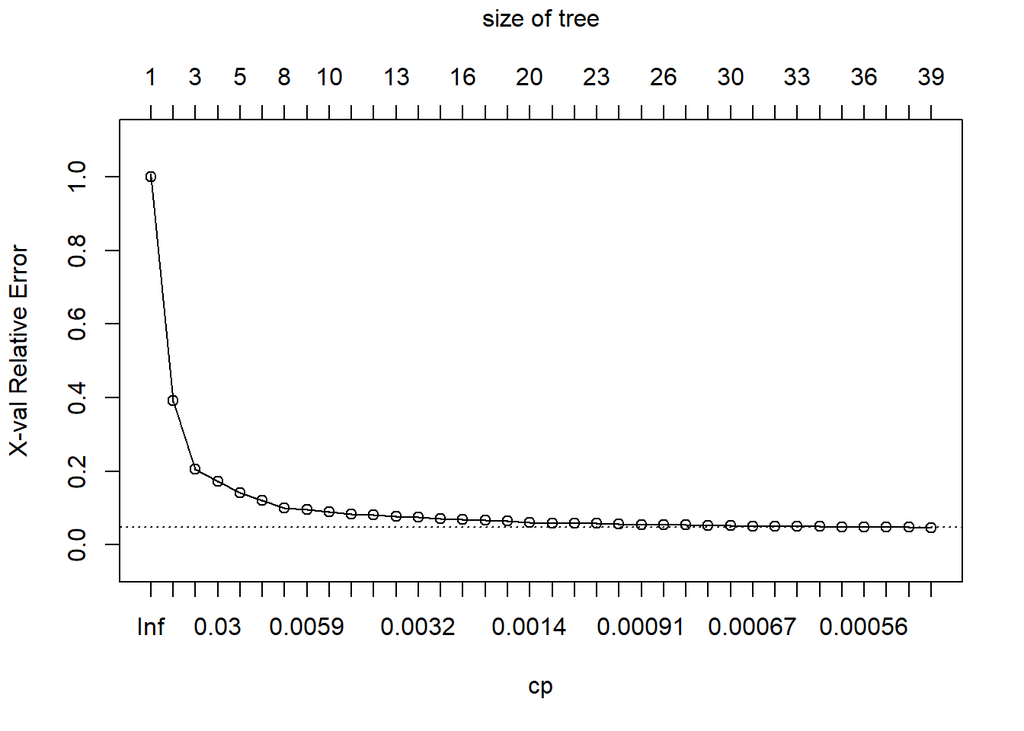

```r
# the shortest way - use a predefined function to plot the xval cp errors
rpart::plotcp(diamond_price_tree_large)
```

In this case our sample is very large so the x-validation error is monotone decreasing (as the CP **decreases**) usually that is not the case.

So far we discussed regression trees, but what happens when we want to use classification?

To measure the error we use the Gini impurity (instead of RSS):

$$G = \sum_{k=1}^K\hat{p}_{mk}(1-\hat{p}_{mk})$$

Where $\hat{p}_{mk}$ is the proportion of observations in the $m$ half space which has a $k$ classification. The measure is lower as $\hat{p}_{mk}$ is more extreme (closer to 0 or to 1).

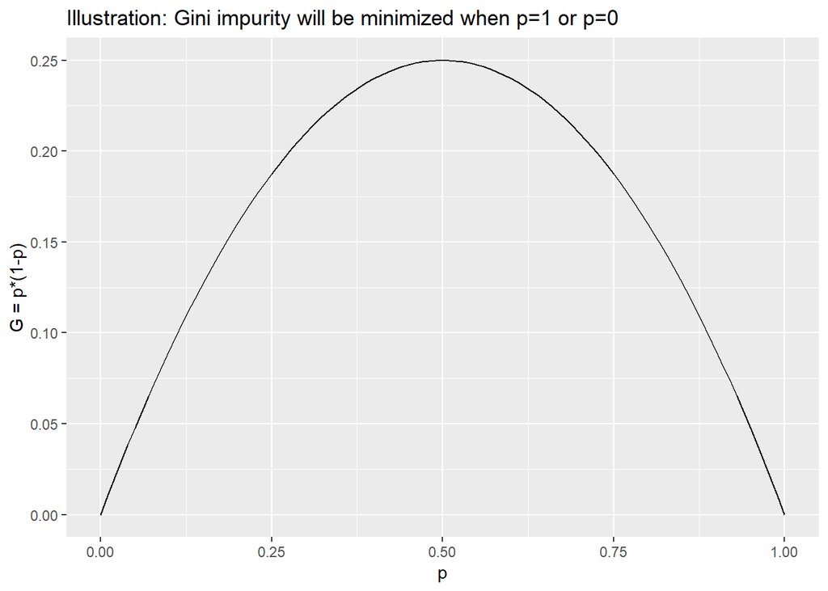

```r
ggplot(tibble(p = seq(0, 1, 0.01)), aes(x = p, y = p*(1-p))) +
  geom_line() +
  ylab("G = p*(1-p)") +
  ggtitle("Illustration: Gini impurity will be minimized when p=1 or p=0")
```

Some algorithms use entropy instead:

$$D = -\sum_{k=1}^K{\hat{p}_{mk}\log\hat{p}_{mk}}$$

### Exercise

In this exercise we will use decision trees to predict the probability for churn.

1. Read the file WA_Fn-UseC_-Telco-Customer-Churn.csv.
2. Build a decision tree to predict churn using a high CP and another tree using a lower CP.
3. Plot the two trees, can you deduce any insights?
4. Show the cross validation error as a functino of CP. What CP would you choose?
5. Split the data to train/test and use the CP you got to fit a tree. Plot an ROC based on the train data and the tree you got.
6. Fit a logistic regression model to predict churn and compare it to the tree you got (plot both of them on the ROC). Which model has a better performance?

```
# q1
telco_churn <- read_csv("https://github.com/adisarid/Riskified_training/raw/master/datasets/WA_Fn-UseC_-Telco-Customer-Churn.csv") %>%
  select(-customerID)

# q2
telco_churn_tree <- rpart(data = telco_churn,
                          formula = Churn ~ .,
                          control = rpart.control(cp = XXX))
# q2+q3
library(rpart.plot)
prp(telco_churn_tree)
telco_churn_short <- prune(telco_churn_tree, cp = XXX)
prp(telco_churn_short)

# q4
printcp(telco_churn_tree)
plotcp(telco_churn_tree)

# q5
telco_churn <- telco_churn %>%
  mutate(is_train = runif(nrow(telco_churn)) < 0.8)

telco_churn_tree_train <- rpart(data = telco_churn %>% filter(is_train),
                                formula = Churn ~ . - is_train,
                                control = rpart.control(cp = XXX))

telco_churn_deeptree_train <- rpart(data = telco_churn %>% filter(is_train),
                                formula = Churn ~ . - is_train,
                                control = rpart.control(cp = XXX))

# Competitive model using logistic regression
telco_churn_glm_train <- glm(formula = (Churn=="Yes") ~ . - is_train,
                             family = binomial,
                             data = telco_churn %>% filter(is_train))

telco_churn_roc <- telco_churn %>%
  mutate(probability_churn_tree = predict(telco_churn_tree_train, newdata = telco_churn)[, "Yes"]) %>%
  arrange(desc(XXX)) %>%
  filter(!is_train) %>%
  mutate(churn_numeric = Churn == "Yes") %>%
  mutate(tpr=XXX,
         fpr=XXX) %>%
  mutate(model = "tree_cp0.01")

telco_churn_roc_deep <- telco_churn %>%
  mutate(probability_churn_deeptree =
           predict(telco_churn_deeptree_train, newdata = telco_churn)[, "Yes"]) %>%
  filter(!is_train) %>%
  mutate(churn_numeric = Churn == "Yes") %>%
  arrange(desc(probability_churn_deeptree)) %>%
  mutate(tpr=cumsum(churn_numeric)/sum(churn_numeric),
         fpr=cumsum(!churn_numeric)/sum(!churn_numeric)) %>%
  mutate(model = "tree_cp0.000001")

telco_churn_roc_glm <- telco_churn %>%
  mutate(probability_churn_glm =
           predict(telco_churn_glm_train, newdata = telco_churn, type = "response")) %>%
  mutate(churn_numeric = Churn == "Yes") %>%
  filter(!is_train) %>%
  arrange(desc(probability_churn_glm)) %>%
  mutate(tpr=cumsum(churn_numeric)/sum(churn_numeric),
         fpr=cumsum(!churn_numeric)/sum(!churn_numeric)) %>%
  mutate(model = "logistic regression")

roc_prep <- telco_churn_roc %>%
  bind_rows(telco_churn_roc_deep,
            telco_churn_roc_glm)


ggplot(roc_prep, aes(x = XXX, y = XXX, color = model)) +
  geom_line() +
  xlab("False positive rate (1 - Specificity)") +
  ylab("True positive rate (Sensitivity)") +
  scale_x_continuous(labels = scales::percent) +
  scale_y_continuous(labels = scales::percent) +
  ggtitle("An ROC for our churn decision tree model") +
  geom_abline(intercept = 0, slope = 1)
```

### Some notes on trees

- Decision trees are “easier” to explain, thanks to their visual nature.
- They can express complex relationships (“if-then”) that regression cannot represent in a strait-forward manner.
- Missing values and factor variables are easily handled.

But

- As a prediction model, they are not that good.
- They are not robust - small changes in the data can lead to an entirely different tree.

Many algorithms build upon decision trees. These algorithms are more robust and usually outperform trees:

- randomForests
- Bagging
- Boosting

## randomForests

The random forest algorithm builds an assortment of many trees, but at each split, the number of splitting variables from which the tree building algorithm chooses is limited to $m$ out of possible $p$ (usually $m\approx \sqrt{p}$).

In addition, the algorithm excludes observations at random for the tree building process.

This method can minimize the effects of local minimum caused by the greedy approach of tree building.

The eventual outcome is the prediction average over all trees.

In addition, we can also compute the average contibution of each variable (the decrease in Gini’s impurity, that each new variable brings).

```r
library(randomForest)
```

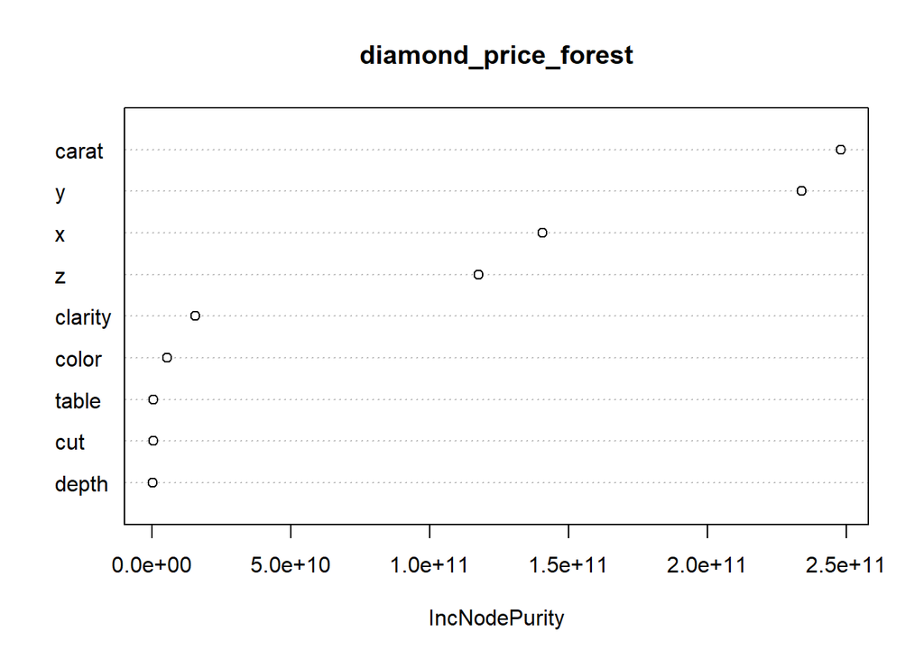

```r
# note the use of maxnodes, otherwise the trees are grown to maximal size
# also limiting the number of trees to 150 - the default is 500...
diamond_price_forest <- randomForest(
  formula = price ~ .,
  data = diamonds,
  maxnodes = 15,
  ntree = 150)

# plot the importance plot
varImpPlot(diamond_price_forest)
```

```r
# show an example of the first tree
getTree(diamond_price_forest, k = 1)
```

```
##    left daughter right daughter split var split point status prediction
## 1              2              3         9       3.915     -3  3954.2386
## 2              4              5         8       5.545     -3  1718.4931
## 3              6              7         9       4.405     -3  8249.2043
## 4              8              9         2       4.500     -3  1064.2314
## 5             10             11         1       0.895     -3  3258.7548
## 6             12             13         9       4.155     -3  6175.6150
## 7             14             15         3       6.500     -3 12114.0299
## 8             16             17         7       4.935     -3  1012.0445
## 9             18             19         8       5.015     -3  1117.6999
## 10            20             21         8       5.725     -3  2742.2207
## 11            22             23         1       0.995     -3  4351.3119
## 12            24             25         3       4.500     -3  5721.7354
## 13            26             27         4       4.500     -3  7121.4596
## 14            28             29         8       7.925     -3 12377.6667
## 15             0              0         0       0.000     -1 10527.9064
## 16             0              0         0       0.000     -1   749.3353
## 17             0              0         0       0.000     -1  1594.6203
## 18             0              0         0       0.000     -1   825.9166
## 19             0              0         0       0.000     -1  1811.9981
## 20             0              0         0       0.000     -1  2463.1655
## 21             0              0         0       0.000     -1  2877.9648
## 22             0              0         0       0.000     -1  3987.1078
## 23             0              0         0       0.000     -1  5208.9190
## 24             0              0         0       0.000     -1  6209.3317
## 25             0              0         0       0.000     -1  4626.6898
## 26             0              0         0       0.000     -1  6230.1941
## 27             0              0         0       0.000     -1  9303.8770
## 28             0              0         0       0.000     -1 11143.5038
## 29             0              0         0       0.000     -1 15410.9750
```

### Exercise

1. Build a random forest for the Telco churn data. Remember to use a train/test split.
2. Compute the type-I and type-II error.
3. Add the results as another ROC line (to the chart you generated in the previous exercise).
   1. Note that when you use the function `predict` you must define the parameter `type` in a specific way. How?
4. Build an importance plot using `varImpPlot`. What parameters are most important to predict churn?
5. Would you consider giving a discount to reduce churn? What % of monthlyCharges would you consider as a discount (if any)?

```
# some help:
# first if you try to replicate the code from the diamond's example, you will get an error.
# this is because randomForest expects no character variables, just numeric and factors.
# So how can we turn everything character into factor?
# Intuitively, you would probably do:

# telco_churn <- telco_churn %>%
#    mutate(gender = as.factor(gender),
#           SeniorCitizen = as.factor(SeniorCitizen),
#           ...)

# but this is like doing the same action over and over again.
# wouldn't it be nice to just loop over everything, and if a column is of the wrong type (character)
# just convert it into factor?
# mutate_if() does exactly that.
# it needs a condition called .predicate, and a vector function to operate called .funs.
# It goes like this:

telco_churn <- telco_churn %>%
   mutate_if(.predicate = funs(typeof(.)=="character"),
             .funs = funs(as.factor(.)))

# What does it do?
# it's like looping
# for (i in 1:NCOL(telco_churn)){
#    if (typeof(telco_churn[,i]) == "character") {
#       telco_churn[,i] <- as.factor(telco_churn[,i])
#    }
# }

# the syntax of
# typeof(.) == "character"
# is like "replace . with the vector you are currently checking"
# the syntax of as.factor(.) is like
# "replace . with the vector" that is a character and you need to type case into a factor
# the funs() function makes the expression explicit after replacing the . with the current vector

# now you can continue the exercise...
```